# A-19012-2019-09-20(1)

19012

9/26/2019

## question

1.Go through “R for Beginners”if you are not familiar with R programming. 2.Use knitr to produce at least 3 examples(texts,figures,tables).

## answer

```r
prof <- c(2119,3196,4423,5472,6068,6588,6914,6710,6819,8344,8888,9319,10979,11999,12597,13097)
num <- c(40,60,80,100,110,120,125,120,120,150,160,170,200,220,230,240)
ad.cost <- c(100,130,200,220,250,260,280,300,330,350,350,340,380,400,420,430)
years <- c(2001:2016)
lm.sol <- lm(prof~num+ad.cost)
summary(lm.sol)$coef
```

```
##                Estimate Std. Error   t value     Pr(>|t|)
## (Intercept) -190.279033 14.4577695 -13.16102 6.851151e-09
## num           49.919657  0.2270819 219.83105 1.347071e-24
## ad.cost        3.060514  0.1379436  22.18670 1.021802e-11
```

```r
knitr::kable(data.frame(years,prof,num,ad.cost))
```

| years | prof | num | ad.cost |
| --- | --- | --- | --- |
| 2001 | 2119 | 40 | 100 |
| 2002 | 3196 | 60 | 130 |
| 2003 | 4423 | 80 | 200 |
| 2004 | 5472 | 100 | 220 |
| 2005 | 6068 | 110 | 250 |
| 2006 | 6588 | 120 | 260 |
| 2007 | 6914 | 125 | 280 |
| 2008 | 6710 | 120 | 300 |
| 2009 | 6819 | 120 | 330 |
| 2010 | 8344 | 150 | 350 |
| 2011 | 8888 | 160 | 350 |
| 2012 | 9319 | 170 | 340 |
| 2013 | 10979 | 200 | 380 |
| 2014 | 11999 | 220 | 400 |
| 2015 | 12597 | 230 | 420 |
| 2016 | 13097 | 240 | 430 |

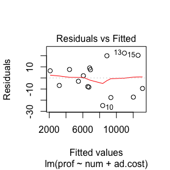

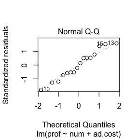

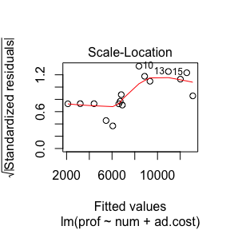

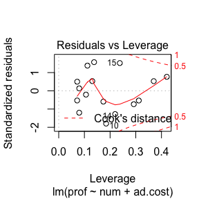

```r
plot(lm.sol)
```

```r
lm.pred <- predict(lm.sol,data.frame(num =240,ad.cost = 440),interval = "prediction",level = 0.95)
lm.pred
```

```
##        fit      lwr      upr
## 1 13137.06 13099.89 13174.24
```

Regarding prof as y,num as x1,ad.cost as x2,then there is y=-190.279033+49.919657x1+3.060514. It shows the relationship between profit, number of people and advertising cost. we can get t-value and p-value. From the above results, the regression coefficient and the regression equation test are significant. Finally, we made a range estimate of profit for the new number of people and the value of advertising cost.

##question Exercies 3.4,3.11 and 3.18

##answers

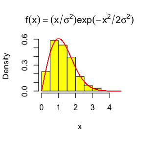

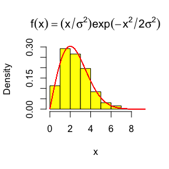

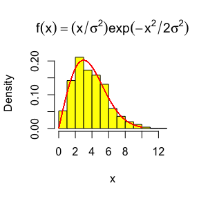

```r
set.seed(3.5)
n <- 1000
sigma <- c(1,2,3)
u <- runif(n)
i <- 1
while (i <= 3) {
  x <- {-2*(sigma[i]^2)*log(1-u)}^{1/2}
  hist(x,prob = TRUE,main = expression(f(x) ==     (x/{sigma^2})*exp(-{x^2}/{2*sigma^2})),col = "YELLOW")
  y <-seq(0,10,.0001,)
  lines(y,{y/{sigma[i]^2}}*exp(-{y^2}/{2*sigma[i]^2}),col = "RED")
  i <- i+1
}
```

The above is the answer to question 3.4.

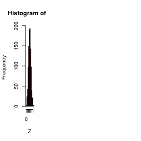

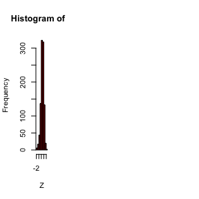

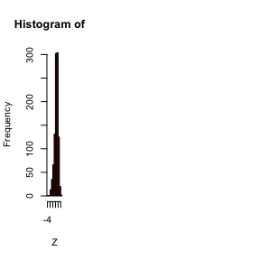

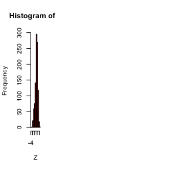

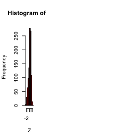

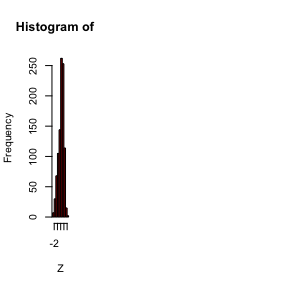

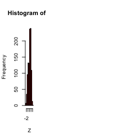

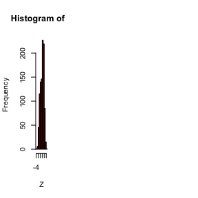

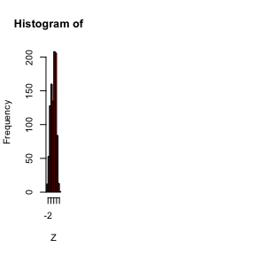

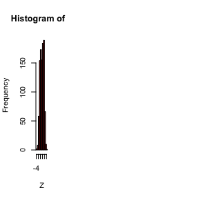

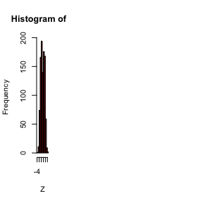

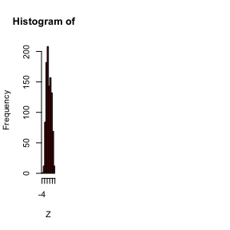

[9 more figures not shown]

```r
set.seed(3.11)
n <- 1e3
X1 <- rnorm(n)
X2 <- rnorm(n,3,1)
i <- 1
p <- seq(0,1,.05)
while (i<= length(p)) {
  r <- sample(c(0,1),n,TRUE,c(1-p[i],p[i]))
  i <- i+1
  Z <- r*X1+(1-r)*X2
 par(mfrow = c(1,3))
 q <- p[i]
  hist(Z,col = "dark RED" )

}
```

The above is the answer to question 3.11. And I conjecture when p is in the range of 0.5 to 0.6, bimodal mixtures appear.

```r
set.seed(3.18)
sigma <- matrix(c(1,.8,.5,.8,2,.6,.5,.6,.3), nrow = 3, ncol = 3,byrow = TRUE)
L <- chol(sigma)
d <- 3
i <- 1
b <- numeric(length(d))
while (i <= 3) {
  b[i] <- (rchisq(1,d-i+1))^(1/2)
  i <- i+1
}
a <- rnorm(3)
A <- matrix(c(b[1],0,0,a[1],b[2],0,a[2],a[3],b[3]), nrow = 3, ncol = 3,byrow = TRUE)
X <- L %*% A %*% t(A) %*% t(L)
cov(X)
```

```
##             [,1]        [,2]         [,3]
## [1,] 0.342745181 0.210873785 3.991352e-03
## [2,] 0.210873785 0.160571400 2.784854e-03
## [3,] 0.003991352 0.002784854 4.999479e-05
```

The above is the answer to question 3.18.

#answer

```r
set.seed(5.1)
n <- 1e4
t <- runif(n,0,pi/3)
theta.hat <- (pi/3)*mean(sin(t))
print(c(theta.hat,1-cos(pi/3)))
```

```
## [1] 0.5015958 0.5000000
```

The value of MC estimate is very close to the exact value of intergral.

```r
set.seed(5.10)
f <- function(u)
  exp(u)/(1+u^2)
m <- 1e3
x <- runif(m)
y <- x[1:(m/2)]
theta.ant <- mean((f(y)+f(1-y))/2)
theta.ant
```

```
## [1] 1.268671
```

```r
mean(f(x))
```

```
## [1] 1.270104
```

```r
sd.ant <- var((f(y)+f(1-y))/2)
sd.without <- var(f(x))
print(c(sd.ant,sd.without,(sd.without-sd.ant)/sd.without))
```

```
## [1] 0.001811462 0.010901970 0.833840875
```

The percentage of the variance without variance reduction is about 83.4%.

```r
set.seed(5.15)
M <- 1e4
k <- 5
N <- 50
T2 <- numeric(k)
est <- matrix(0,N,2)
x <- matrix(0,k,M/k)
f <- function(u, i)
  exp(-u)/(exp(-(i-1)/k)-exp(-i/k))
g <- function(u)
  exp(-u)/(1+u^2)
for(i in 1:N) {
  est[i,1] <- mean(g(runif(M)))
  for (j in 1:k) {
    u <- runif(M/k)
    x[j,] <- -log(exp(-(j-1)/k)-(exp(-(j-1)/k)-exp(-j/k))*u)
    T2[j] <- mean(g(x[j,])/f(x[j,], j))
  }
  est[i,2] <- sum(T2)
}
est
```

```
##            [,1]      [,2]
##  [1,] 0.5234202 0.5249230
##  [2,] 0.5298015 0.5247032
##  [3,] 0.5275929 0.5248124
##  [4,] 0.5249217 0.5253175
##  [5,] 0.5264730 0.5248058
##  [6,] 0.5277890 0.5250647
##  [7,] 0.5278217 0.5247462
##  [8,] 0.5298864 0.5248893
##  [9,] 0.5251538 0.5248931
## [10,] 0.5286374 0.5245540
## [11,] 0.5227432 0.5247961
## [12,] 0.5218220 0.5248605
## [13,] 0.5244587 0.5245813
## [14,] 0.5211569 0.5247606
```

[output cut: 36 more lines]

```r
colMeans(est)
```

```
## [1] 0.5252438 0.5248320
```

```r
apply(est,2,sd)
```

```
## [1] 0.002829940 0.000160576
```

```r
#example 5.10
m <- 10000
g <- function(x) {
    exp(-x - log(1+x^2))*(x>0)*(x<1)
    }
u <- runif(m) #f3, inverse transform method
x <- - log(1 - u * (1 - exp(-1)))
fg <- g(x) / (exp(-x) / (1 - exp(-1)))
theta.hat <- mean(fg)
se <- sd(fg)
print(c(theta.hat,se))
```

```
## [1] 0.52440941 0.09697615
```

First stratifing, each strata uses importance sampling, considering that each strata of importance function should satisfy the probability density, so each strata function is designed as (exp(-x))/(exp(-(i-1)/k)-exp(-i/k)),where k is the total number of strata, i is the i-th strata.

The variance of stratified importance sampling estimate is much smaller than importance sampling.

##question 6.5 Suppose a 95% symmetric t-interval is applied to estimate a mean, but the sample data are non-normal. Then the probability that the confidence interval covers the mean is not necessarily equal to 0.95. Use a Monte Carlo experiment to estimate the coverage probability of the t-interval for random samples of χ2(2) data with sample size n = 20. Compare your t-interval results with the simulation results in Example 6.4. (The t-interval should be more robust to departures from normality than the interval for variance.)

6.6 Estimate the 0.025, 0.05, 0.95, and 0.975 quantiles of the skewness b1 under normality by a Monte Carlo experiment. Compute the standard error of the estimates from (2.14) using the normal approximation for the density (with exact variance formula). Compare the estimated quantiles with the quantiles of the large sample approximation √b1 ≈ N (0, 6/n).

##answer 6.5

```r
n <- 20
alpha <- .05
mu <- 2
UCL <- numeric(1e4)
for (i in 1:1e4) {
  x <- rchisq(n,2)
  UCL[i] <- as.integer(abs((mean(x) - mu)/(sd(x)/sqrt(n))) < qt(.975, n-1))}
print(mean(UCL))
```

```
## [1] 0.9171
```

Using a 95% symmetric t-interval is applied to estimate a mean,and x for χ2(2) with MC experiment And we can see the result of mine is better than example 6.4,this say the t-interval is more robust to departures from normality than the interval for variance.

```r
n <- 20
qua <- c(0.025, 0.05, 0.95, 0.975)
v.qua <- numeric(length(qua))
for (i in 1:length(qua)) {
  v.qua[i] <- qnorm(qua[i],0,sqrt(6*(n-2) / ((n+1)*(n+3))))
  }
v.qua
```

```
## [1] -0.9268008 -0.7777958  0.7777958  0.9268008
```

```r
x <- sort(rnorm(1e5,0,sqrt(6*(n-2) / ((n+1)*(n+3)))))
x[qua * 1e5]
```

```
## [1] -0.9309035 -0.7797589  0.7804971  0.9278986
```

```r
##
se.hat <- numeric(length(n))
for(i in 1:length(qua)){
  se.hat[i] <- (qua[i]*(1-qua[i])/(n*(dnorm(v.qua[i]))^2))^(1/2)
}
se.hat
```

```
## [1] 0.1344522 0.1653060 0.1653060 0.1344522
```

1.produce 100000 sample from N(0,sqrt(6*(n-2) / ((n+1)*(n+3)))) 2.compare x[c(2500,5000,95000,97500)] and qnorm(,c(0.025, 0.05, 0.95, 0.975),0,sqrt(6*(n-2) / ((n+1)*(n+3)))),we can see the result is very close to the true value. 3. Compute the standard error of the estimates from (2.14) using the normal approximation for the density

$$question 6.7 Estimate the power of the skewness test of normality against symmetric Beta(α, α) distributions and comment on the results. Are the results different for heavy-tailed symmetric alternatives such as t(ν)?

6.A Use Monte Carlo simulation to investigate whether the empirical Type I error rate of the t-test is approximately equal to the nominal significance level α, when the sampled population is non-normal. The t-test is robust to mild departures from normality. Discuss the simulation results for the cases where the sampled population is (i) χ2(1), (ii) Uniform(0,2), and (iii) Exponen- tial(rate=1). In each case, test H0 : μ = μ0 vs H0 : μ ̸= μ0, where μ0 is the mean of χ2(1), Uniform(0,2), and Exponential(1), respectively.

$$answer

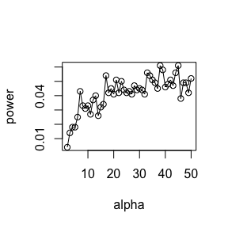

```r
##beta
set.seed(6.7)
alpha <- c(seq(2,50,1))#Beta distribution's parameter
alpha1 <- 0.05 #significance level
power <- numeric(length(alpha))
m <- 1e3
p.val <- numeric(m)
n <- 20
sk <- function(x) {
  xbar <- mean(x)
  m3 <- mean((x - xbar)^3)
  m2 <- mean((x - xbar)^2)
  return( m3 / m2^1.5 ) }
for (i in 1:length(alpha)) {
  for (j in 1:m) {
    x <- rbeta(n,alpha[i],alpha[i])
    p.val[j] <- 2*(1 - pnorm(abs(sk(x)/sqrt(6*(n-2) / ((n+1)*(n+3))))))
  }
  power[i] <- mean(p.val <= alpha1)

}
plot(alpha, power, type = 'l')
points(alpha, power)
```

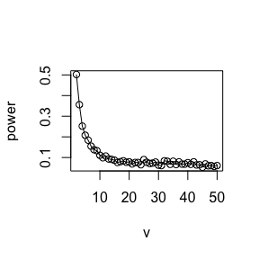

```r
##t
v <- c(seq(2,50,1))#Beta distribution's parameter
alpha1 <- 0.05 #significance level
power <- numeric(length(v))
p.val <- numeric(m)
m <- 1e3
n <- 20
sk <- function(x) {
  xbar <- mean(x)
  m3 <- mean((x - xbar)^3)
  m2 <- mean((x - xbar)^2)
  return( m3 / m2^1.5 ) }
for (i in 1:length(v)) {
  for (j in 1:m) {
    x <- rt(n,v[i])
    p.val[j] <- 2*(1 - pnorm(abs(sk(x)/sqrt(6*(n-2) / ((n+1)*(n+3))))))
  }
  power[i] <- mean(p.val <= alpha1)

}
plot(v, power, type = 'l')
points(v, power)
```

From above result,we can see Beta(α, α) distribution tends to be symmetrical ,when When alpha becomes smaller.Conversely, when v increases, the t(v) distribution tends to be symmetric.

```r
set.seed(6.001)
##χ2(1)
n <- 20
alpha <- .05
mu0 <- 1
m <- 10000
p <- numeric(m)
for (j in 1:m) {
  x <- rchisq(n, 1)
  ttest <- t.test(x, alternative = "greater",mu = mu0)
  p[j] <- ttest$p.value
}
p.hat <- mean(p < alpha)
print(p.hat)
```

```
## [1] 0.0141
```

```r
##Uniform(0,2)
for (j in 1:m) {
  x <- runif(n, 0,2)
  ttest <- t.test(x, alternative = "greater",mu = mu0)
  p[j] <- ttest$p.value
}
p.hat <- mean(p < alpha)
print(p.hat)
```

```
## [1] 0.0487
```

```r
##Exponential(1)
for (j in 1:m) {
  x <- rexp(n, 1)
  ttest <- t.test(x, alternative = "greater",mu = mu0)
  p[j] <- ttest$p.value
}
p.hat <- mean(p < alpha)
print(p.hat)
```

```
## [1] 0.0185
```

From above,we can see Uniform(0,2) distribution’s empirical Type I error rate of the t-test is approximately equal to the nominal significance level α,but others are not equal to.

##question

If we obtain the powers for two methods under a particular simulation setting with 1,0000 experiments: say,0.651 for one method and 0.676 for another method. Can we say the powers are different at 0.05 level?

1.What is the corresponding hypothesis test problem?

2.What test should we use? Z-test,two-sample t-test,paired-t test or McNemar test?

3.What information is needed to test your hypothesis?

##answer

1.Whether the difference between the two p values is 0.

2.two-sample t-test.Because there are two random variables,and they are not one-to-one.

3.Real distribution of random variables.If we know the real distribution of random variables,when the null hypothesis is established, the p-value is subject to uniform (0,1).

$$Questions

7.6 Efron and Tibshirani discuss the scor (bootstrap) test score data on 88 stu- dents who took examinations in five subjects [84, Table 7.1], [188, Table 1.2.1]. The first two tests (mechanics, vectors) were closed book and the last three tests (algebra, analysis, statistics) were open book. Each row of the data frame is a set of scores (xi1,…,xi5) for the ith student. Use a panel display to display the scatter plots for each pair of test scores. Compare the plot with the sample correlation matrix. Obtain bootstrap estimates of the standard errors for each of the following estimates: ρˆ12 = ρˆ(mec, vec), ρˆ34 = ρˆ(alg, ana), ρˆ35 = ρˆ(alg, sta), ρˆ45 = ρˆ(ana, sta).

7.B Repeat Project 7.A for the sample skewness statistic. Compare the coverage rates for normal populations (skewness 0) and χ2(5) distributions (positive skewness).

$$answer

7.6

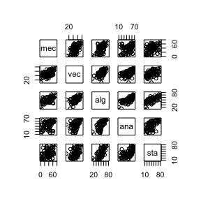

```r
set.seed(7.6)
library(boot)
library(bootstrap)
pairs(scor)#matrix of scatter plots
```

```r
cor(scor)#sample correlation matrix
```

```
##           mec       vec       alg       ana       sta
## mec 1.0000000 0.5534052 0.5467511 0.4093920 0.3890993
## vec 0.5534052 1.0000000 0.6096447 0.4850813 0.4364487
## alg 0.5467511 0.6096447 1.0000000 0.7108059 0.6647357
## ana 0.4093920 0.4850813 0.7108059 1.0000000 0.6071743
## sta 0.3890993 0.4364487 0.6647357 0.6071743 1.0000000
```

```r
b.cor <- function(x,i)
  cor(x[i,1],x[i,2])
obj.12 <- boot(data = scor,statistic = b.cor,R = 2000)
round(c(se.12 = sd(obj.12$t)),3)
```

```
## se.12
## 0.076
```

```r
b.cor <- function(x,i)
  cor(x[i,3],x[i,4])
obj.34 <- boot(data = scor,statistic = b.cor,R = 2000)
round(c(se.34 = sd(obj.34$t)),3)
```

```
## se.34
## 0.049
```

```r
b.cor <- function(x,i)
  cor(x[i,3],x[i,5])
obj.35 <- boot(data = scor,statistic = b.cor,R = 2000)
round(c(se.35 = sd(obj.35$t)),3)
```

```
## se.35
## 0.059
```

```r
b.cor <- function(x,i)
  cor(x[i,4],x[i,5])
obj.45 <- boot(data = scor,statistic = b.cor,R = 2000)
round(c(se.45 = sd(obj.45$t)),3)
```

```
## se.45
## 0.068
```

1.The closer the absolute value of the correlation coefficient is to 1, the closer the scatter plot is to a straight line. 2.The required correlation coefficient is as shown above.

7.B

```r
set.seed(7.01)
#normal population
library(boot)
library(bootstrap)
n <- 20
sk <- function(x,i) {
  xbar <- mean(x[i])
  m3 <- mean((x[i] - xbar)^3)
  m2 <- mean((x[i] - xbar)^2)
  return( m3 / m2^1.5 ) }
m <- 1000
ci.norm <- ci.basic <- ci.perc <- matrix(NA,m,2)
mu <- 0#expection of N(0,2) dstribution's skewness
for (i in 1:m) {
  x <- rnorm(n,0,2)
  boot.obj <- boot(data = x,statistic = sk,R = 2000)
  ci <- boot.ci(boot.obj,type = c("basic","norm","perc"))
  ci.norm[i,] <- ci$norm[2:3]
  ci.basic[i,] <- ci$basic[4:5]
  ci.perc[i,] <- ci$percent[4:5]
}
cat('norm =',mean(ci.norm[,1]<=mu & ci.norm[,2]>= mu),
    'basic =',mean(ci.basic[,1]<=mu & ci.basic[,2]>=mu),
    'perc =',mean(ci.perc[,1]<=mu & ci.perc[,2]>=mu))
```

```
## norm = 0.884 basic = 0.881 perc = 0.964
```

```r
left.norm <- mean(ci.norm[,1] > mu)
right.norm <- mean(ci.norm[,2] < mu)
left.basic <- mean(ci.basic[,1] > mu)
right.basic <- mean(ci.basic[,2] < mu)
left.perc <- mean(ci.perc[,1] > mu)
right.perc <-  mean(ci.perc[,2] < mu)
print(c('left.norm'=left.norm,'right.norm'=right.norm,'left.basic'=left.basic,'right.basic'=right.basic,'left.perc'=left.perc,'right.perc'=right.perc))
```

```
##   left.norm  right.norm  left.basic right.basic   left.perc  right.perc
##       0.061       0.055       0.061       0.058       0.017       0.019
```

```r
#χ2(5)
sk <- function(x,i) {
  xbar <- mean(x[i])
  m3 <- mean((x[i] - xbar)^3)
  m2 <- mean((x[i] - xbar)^2)
  return( m3 / m2^1.5 ) }
m <- 1000
ci.norm <- ci.basic <- ci.perc <- matrix(NA,m,2)
mu <- sqrt(8/5)#expection of χ2(5) dstribution's skewness
for (i in 1:m) {
  x <- rchisq(n,5)
  boot.obj <- boot(data = x,statistic = sk,R = 2000)
  ci <- boot.ci(boot.obj,type = c("basic","norm","perc"))
  ci.norm[i,] <- ci$norm[2:3]
  ci.basic[i,] <- ci$basic[4:5]
  ci.perc[i,] <- ci$percent[4:5]
}
cat('norm =',mean(ci.norm[,1]<=mu & ci.norm[,2]>= mu),
    'basic =',mean(ci.basic[,1]<=mu & ci.basic[,2]>=mu),
    'perc =',mean(ci.perc[,1]<=mu & ci.perc[,2]>=mu))
```

```
## norm = 0.707 basic = 0.681 perc = 0.697
```

```r
left.norm <- mean(ci.norm[,1] > mu)
right.norm <- mean(ci.norm[,2] < mu)
left.basic <- mean(ci.basic[,1] > mu)
right.basic <- mean(ci.basic[,2] < mu)
left.perc <- mean(ci.perc[,1] > mu)
right.perc <-  mean(ci.perc[,2] < mu)
print(c('left.norm'=left.norm,'right.norm'=right.norm,'left.basic'=left.basic,'right.basic'=right.basic,'left.perc'=left.perc,'right.perc'=right.perc))
```

```
##   left.norm  right.norm  left.basic right.basic   left.perc  right.perc
##       0.009       0.284       0.024       0.295       0.000       0.303
```

1.Coverage rate as above 2.normal populalution has much better effect than χ2(5) distribution.

$$question 7.8 Refer to Exercise 7.7. Obtain the jackknife estimates of bias and standard error of θˆ.

7.10 In Example 7.18, leave-one-out (n-fold) cross validation was used to select the best fitting model. Repeat the analysis replacing the Log-Log model with a cubic polynomial model. Which of the four models is selected by the cross validation procedure? Which model is selected according to maximum adjusted R^2?

$$answer

```r
set.seed(7.7)
library(bootstrap)
n <- nrow(scor)
mat <- as.matrix(scor) ##define matrix
value <- val.hat <- numeric(5)
val.jack <- matrix(0,n,5)
sita.j <- numeric(n)
for (i in 1:n) {
  value <- eigen(cor(mat[-i,]))$value
  val.jack[i,] <- sort(value,decreasing = T)
  sita.j[i] <- val.jack[i,1]/sum(val.jack[i,])
}##obtain sita.hat by jackknife
sita.jack <- mean(sita.j)
lambda <- sort(eigen(cor(mat))$value,decreasing = T)
sita.hat <- lambda[1]/sum(lambda)
bias.jack <- (n-1)*(mean(sita.jack)-sita.hat) ##bias
se.jack <- sqrt((n-1)*mean((sita.j-sita.hat)^2)) ##se
round(c(bias.jack = bias.jack,se.jack = se.jack),5)
```

```
## bias.jack   se.jack
##  -0.00038   0.04467
```

The above results show that jackknife works very well.

```r
library(DAAG)
attach(ironslag)
n <- length(magnetic)
e1 <- e2 <- e3 <- e4 <- R1 <- R2 <- R3 <- R4 <- T1 <- T2 <- T3 <- T4 <- yhat1 <- yhat2 <- yhat3 <- yhat4 <- numeric(n)
for (k in 1:n) {
  y <- magnetic[-k]
  x <- chemical[-k]
  ##linear
  J1 <- lm(y ~ x)
  yhat1[k] <- J1$coef[1] + J1$coef[2] * chemical[k]
  e1[k] <- magnetic[k] - yhat1[k]
  R1[k] <- (yhat1[k]-mean(magnetic))^2
  T1[k] <- (magnetic[k]-mean(magnetic))^2
  ##quadratic polynomial
  J2 <- lm(y ~ x + I(x^2))
  yhat2[k] <- J2$coef[1] + J2$coef[2] * chemical[k] + J2$coef[3] * chemical[k]^2
  e2[k] <- magnetic[k] - yhat2[k]
  R2[k] <- (yhat2[k]-mean(magnetic))^2
  T2[k] <- (magnetic[k]-mean(magnetic))^2
 ##log-log
  J3 <- lm(log(y) ~ x)
  logyhat3 <- J3$coef[1] + J3$coef[2] * chemical[k]
  yhat3[k] <- exp(logyhat3)
  e3[k] <- magnetic[k] - yhat3[k]
  R3[k] <- (yhat3[k]-mean(magnetic))^2
  T3[k] <- (magnetic[k]-mean(magnetic))^2
  ## cubic polynomial model
  J4 <- lm(y ~ x + I(x^2) + I(x^3))
  yhat4[k] <- J4$coef[1] + J4$coef[2] * chemical[k] + J4$coef[3] * chemical[k]^2 + J4$coef[4] * chemical[k]^3
  e4[k] <- magnetic[k] - yhat4[k]
  R4[k] <- (yhat4[k]-mean(magnetic))^2
  T4[k] <- (magnetic[k]-mean(magnetic))^2
}
error.square <- c(mean(e1^2), mean(e2^2), mean(e3^2), mean(e4^2))
R.square <- c(sum(R1)/sum(T1)*51/50, sum(R2)/sum(T2)*51/49, sum(R3)/sum(T3)*51/50, sum(R4)/sum(T4)*41/48)## adjusted R^2 = (SSE/n-p-1)/(SST/n-1)

models <- c("linear","quadratic polynomial","log-log","cubic polynomial")
data.frame(models,error.square,R.square)
```

```
##                 models error.square  R.square
## 1               linear     19.55644 0.5450654
## 2 quadratic polynomial     17.85248 0.5944676
## 3              log-log     18.44188 0.4676507
## 4     cubic polynomial     18.17756 0.4677449
```

Acrossing to $R^{2}$,quadratic polynomial is the best fitting model.

```r
x <- c(158,171,193,199,230,243,248,248,250,267,271,316,327,329)
y <- c(141,148,169,181,203,213,229,244,257,260,271,309)
R <- 999
z <- c(x,y)
K <- 1:length(z)
n <- length(x)
reps <- numeric(R)
t0 <- t.test(x,y)$statistic
for (i in 1:R) {
  k <- sample(K, size = n,replace = FALSE)
  x1 <- z[k]
  y1 <- z[-k]
  reps[i] <- t.test(x1,y1)$statistic

}
p <- mean(abs(c(t0,reps)) >= abs(t0))
round(c(p,t.test(x,y)$p.value),3)
```

```
## [1] 0.201 0.198
```

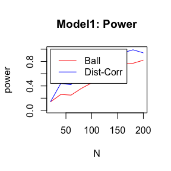

```r
library(Ball)
library(boot)
dCov <- function(x, y) {
  x <- as.matrix(x); y <- as.matrix(y)
  n <- nrow(x); m <- nrow(y)
  if (n != m || n < 2) stop("Sample sizes must agree")
  if (! (all(is.finite(c(x, y))))) stop("Data contains missing or infinite values")
  Akl <- function(x) {
    d <- as.matrix(dist(x))
    m <- rowMeans(d); M <- mean(d)
    a <- sweep(d, 1, m); b <- sweep(a, 2, m)
    b + M
  }
  A <- Akl(x); B <- Akl(y)
  sqrt(mean(A * B))
}
ndCov2 <- function(z, ix, dims) {
  #dims contains dimensions of x and y
  p <- dims[1]
  q <- dims[2]
  d <- p + q
  x <- z[ , 1:p] #leave x as is
  y <- z[ix, -(1:p)] #permute rows of y
  return(nrow(z) * dCov(x, y)^2)
}
ns <- seq(20, 200, 20); M = 100;
P <- matrix(0, length(ns), 2)
for(m in 1:M) {
  p <- matrix(0, length(ns), 2)
  for(i in 1:length(ns)) {
    # data generate
    n <- ns[i]
    x1 <- rnorm(n); x2 <- rnorm(n); x <- cbind(x1, x2)
    e1 <- rnorm(n); e2 <- rnorm(n); e <- cbind(e1, e2)
    # Model2
    y <- x / 4 + e
    z <- cbind(x, y)
    # Ball test
    p[i, 1] <- bcov.test(z[,1:2],z[,3:4],num.permutations=99,seed=i*m*42)$p.value
    # permutatin: resampling without replacement
    boot.obj <- boot(data = z, statistic = ndCov2, R = 99,
                     sim = "permutation", dims = c(2, 2))
    tb <- c(boot.obj$t0, boot.obj$t)
    p[i, 2] <- mean(tb>=tb[1])
  }
  P <- P + (p <= 0.05)
}
P <- P / M
plot(ns, P[, 1], type = 'l', col = 'red', ylim = c(0, 1), xlab = "N", ylab = "power")
lines(ns, P[, 2], col = 'blue')
title(main = "Model1: Power")
legend(20, 1, legend = c("Ball", "Dist-Corr"), lty = 1, col = c("red", "blue"))
```

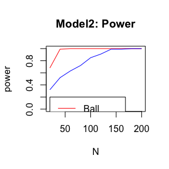

```r
P <- matrix(0, length(ns), 2)
for(m in 1:M) {
  p <- matrix(0, length(ns), 2)
  for(i in 1:length(ns)) {
    # data generate
    n <- ns[i]
    x1 <- rnorm(n); x2 <- rnorm(n); x <- cbind(x1, x2)
    e1 <- rnorm(n); e2 <- rnorm(n); e <- cbind(e1, e2)
    # Model2
    y <- x / 4 * e
    z <- cbind(x, y)
    # Ball test
    p[i, 1] <- bcov.test(z[,1:2],z[,3:4],num.permutations=99,seed=i*m*42)$p.value
    # permutatin: resampling without replacement
    boot.obj <- boot(data = z, statistic = ndCov2, R = 99,
                     sim = "permutation", dims = c(2, 2))
    tb <- c(boot.obj$t0, boot.obj$t)
    p[i, 2] <- mean(tb>=tb[1])
  }
  P <- P + (p <= 0.05)
}
P <- P / M
plot(ns, P[, 1], type = 'l', col = 'red', ylim = c(0, 1), xlab = "N", ylab = "power")
lines(ns, P[, 2], col = 'blue')
title(main = "Model2: Power")
legend(20, 0.2, legend = c("Ball", "Dist-Corr"), lty = 1, col = c("red", "blue"))
```

$Question$ $Implement a random walk Metropolis sampler for generating the standard Laplace distribution (see Exercise 3.2). For the increment, simulate from a normal distribution. Compare the chains generated when different variances are used for the proposal distribution. Also, compute the acceptance rates of each chain.$

$answer$

```r
set.seed(7.4)
library(distr)  # distr package can generate Laplace distribution and quantile
D <- DExp(1) # generate the target function
rw.Metropolis <- function(n, sigma, x0, N) {
        x <- numeric(N)
        x[1] <- x0
        u <- runif(N)
        k <- 0
        for (i in 2:N) {
            y <- rnorm(1, x[i-1], sigma)
            if (u[i] <= (d(D)(y) / d(D)(x[i-1])))
                x[i] <- y  else {
                    x[i] <- x[i-1]
                    k <- k + 1
                }
            }
        return(list(x=x, k=k))
        }
    n <- 4  #degrees of freedom for target Student t dist.
    N <- 2000
    sigma <- c(.05, .2, 1, 4,  16) #different sigma

    x0 <- 25
    rw1 <- rw.Metropolis(n, sigma[1], x0, N)
    rw2 <- rw.Metropolis(n, sigma[2], x0, N)
    rw3 <- rw.Metropolis(n, sigma[3], x0, N)
    rw4 <- rw.Metropolis(n, sigma[4], x0, N)
    rw5 <- rw.Metropolis(n, sigma[5], x0, N)


    print(c(rw1$k, rw2$k, rw3$k, rw4$k,rw5$k))#number of candidate points rejected
```

```
## [1]   35  127  600 1307 1805
```

```r
    print((N-c(rw1$k, rw2$k, rw3$k, rw4$k,rw5$k))/N) #acceptance rates of candidate points
```

```
## [1] 0.9825 0.9365 0.7000 0.3465 0.0975
```

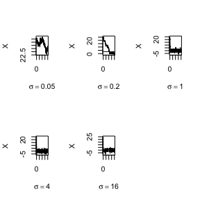

```r
    par(mfrow=c(2,3))  #display 4 graphs together
    refline <- q(D)(c(.025, .975))
    rw <- cbind(rw1$x, rw2$x, rw3$x,  rw4$x,rw5$x)
    for (j in 1:5) {
        plot(rw[,j], type="l",
             xlab=bquote(sigma == .(round(sigma[j],3))),
             ylab="X", ylim=range(rw[,j]))
        abline(h=refline)
    }
    par(mfrow=c(1,1)) #reset to default
```

##question 11.1 The natural logarithm and exponential functions are inverses of each other, so that mathematically log(exp x) = exp(log x) = x. Show by example that this property does not hold exactly in computer arithmetic. Does the identity hold with near equality? (See all.equal.)

11.5 、Write a function to solve the equation
$$\begin{aligned} \frac{2 \Gamma\left(\frac{k}{2}\right)}{\sqrt{\pi(k-1)} \Gamma\left(\frac{k-1}{2}\right)} \int_{0}^{c_{k-1}}\left(1+\frac{u^{2}}{k-1}\right)^{-k / 2} d u & = & \frac{2 \Gamma\left(\frac{k+1}{2}\right)}{\sqrt{\pi k} \Gamma\left(\frac{k}{2}\right)} \int_{0}^{c_{k}}\left(1+\frac{u^{2}}{k}\right)^{-(k+1) / 2} d u \end{aligned}$$
for a, where
$$c_{k}=\sqrt{\frac{a^{2} k}{k+1-a^{2}}}$$
Compare the solutions with the points A(k) in Exercise 11.4.

q3 A-B-O blood type problem Let the three alleles be A, B and O with allele frequencies p, q and r. The 6 genotype frequencies under HWE and complete counts are as follows.

Genotype AA BB OO AO BO AB Sum

Frequency p^2 q^2 r^2 2pr 2qr 2pq 1

Count nAA nBB nOO nAO nBO nAB n

Observed data: nA· = nAA + nAO = 28 (A-type),

nB· = nBB + nBO = 24 (B-type), nOO = 41 (O-type),

nAB = 70 (AB-type).

1. Use EM algorithm to solve MLE of p and q (consider missing data nAA and nBB).
2. Show that the log-maximum likelihood values in M-steps are increasing via line plot.

##answer

```r
n <- 1e3
x <- runif(n,0,100)
y <- log(exp(x))
z <- exp(log(x))
isTRUE(y == z)
```

```
## [1] FALSE
```

```r
isTRUE(y == x)
```

```
## [1] FALSE
```

```r
isTRUE(z == x)
```

```
## [1] FALSE
```

```r
isTRUE(all.equal(y,z))
```

```
## [1] TRUE
```

```r
isTRUE(all.equal(y,x))
```

```
## [1] TRUE
```

```r
isTRUE(all.equal(x,z))
```

```
## [1] TRUE
```

From the above data, we can know that the function values are not exactly equal, but they are approximately equal because the computer uses binary.

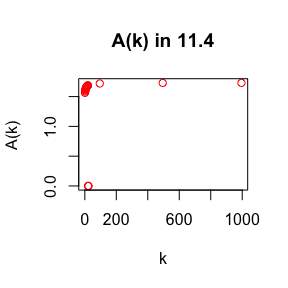

```r
#11.4
p.b <- numeric(24)
for (k in c(5:25,100,500,1000)) {
  #coefficient
  fgma <- function(x){
  return(exp(log(2)+lgamma(x/2)-(1/2)*(log(pi * (x-1)))-lgamma((x-1)/2)))
}
func <- function(y)
  #function
  (fgma(k)*integrate(function(x)(1 + (x^2)/(k-1))^(-k/2),lower = sqrt((y^2)*(k-1)/(k-y^2)),upper = Inf)$value)-(fgma(k+1)*integrate(function(x)(1 + (x^2)/k)^(-(k+1)/2),lower = sqrt((y^2)*k/(k+1-y^2)),upper = Inf)$value)
p.b[k-4] <- uniroot(func,lower = 0.1,upper = 1+sqrt(k)/2)$root
}
plot(p.b[-1],main = "A(k) in 11.4",col = "RED",xlab = "k",ylab = "A(k)")
```

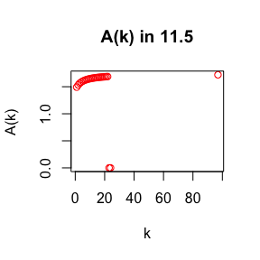

```r
#11.5
p.a <- numeric(24)
for (k in c(4:25,100)) {
  fgma <- function(x){
  return(exp(log(2)+lgamma(x/2)-(1/2)*(log(pi * (x-1)))-lgamma((x-1)/2)))
}
func <- function(y)
  (fgma(k)*integrate(function(x)(1 + (x^2)/(k-1))^(-k/2),lower = 0,upper = sqrt((y^2)*(k-1)/(k-y^2)))$value)-(fgma(k+1)*integrate(function(x)(1 + (x^2)/k)^(-(k+1)/2),lower = 0,upper = sqrt((y^2)*k/(k+1-y^2)))$value)
p.a[k-3] <- uniroot(func,lower = 0.1,upper = 1+sqrt(k)/2)$root
}
plot(p.a,main = "A(k) in 11.5",col = "RED",xlab = "k",ylab = "A(k)")
```

```r
print(p.b[which(p.b>0)])
```

```
##  [1] 1.533582 1.562755 1.584431 1.601173 1.614503 1.625383 1.634421 1.642052
##  [9] 1.648550 1.654150 1.659112 1.663443 1.667277 1.670723 1.673824 1.676613
## [17] 1.679147 1.681500 1.683591 1.685546 1.687346 1.720614 1.729751 1.730897
```

```r
print(p.a[which(p.a>0)])
```

```
##  [1] 1.492105 1.533582 1.562755 1.584431 1.601173 1.614503 1.625383 1.634421
##  [9] 1.642052 1.648550 1.654150 1.659112 1.663443 1.667277 1.670723 1.673824
## [17] 1.676613 1.679147 1.681500 1.683591 1.685546 1.687346 1.720614
```

As k increases, A (K) slowly approaches a value，and the value from 11.4 and 11.5 is approximately equal.

```r
n.A <- 28
n.B <- 24
n.OO <- 41
n.AB <- 70
#Log - likelihood function
llk <- function(theta ,n.AO ,n.BO){
  p <- theta[1]
  q <- theta[2]
  return(-(2*n.A*log(p) + 2*n.B*log(q) + 2*n.OO*log(1-p-q) + n.AO*log((1-p-q)/p) + n.BO*log((1-p-q)/q) +n.AB*log(p*q)))
}
st <- 1#step
er <- 1#error
N <- 1000
p1 <- q1 <- numeric(N)
#initial value (random value and less than 1)
p1[1] <- 0.1
q1[1] <- 0.1
#EM algorithm
while (er > 1e-5 && st < N ) {
  p <- p1[st]
  q <- q1[st]
  #n.AO and n.BO subject to B distribution(parameter is below)
  theta <- c(p,q)
  n.AO <- n.A * (1 - (p/(2-p-2*q)))
  n.BO <- n.B * (1 - (q/(2-2*p-q)))
  #p and q mle
  mle <- optim(theta,llk, n.AO = n.AO, n.BO = n.BO)
  theta <- mle$par
  st <- st + 1
  p1[st] <- theta[1]
  q1[st] <- theta[2]
  #compute error
  er <- min(abs(p1[st] - p1[st - 1]),abs(q1[st] - q1[st - 1]))
}
c(p,q,1-p-q)
```

```
## [1] 0.3273296 0.3104582 0.3622123
```

Data is above.

# questions

3. Use both for loops and lapply() to fit linear models to the mtcars using the formulas stored in this list: formulas <- list( mpg ~ disp, mpg ~ I(1 / disp), mpg~disp+wt, mpg~I(1/disp)+wt )
4. Fit the model mpg ~ disp to each of the bootstrap replicates of mtcars in the list below by using a for loops and lapply(). Can you do it without an anonymous function? bootstraps <- lapply(1:10, function(i) { rows <- sample(1:nrow(mtcars), rep = TRUE) mtcars[rows, ] })
5. For each model in the previous two exercises, extract R2 using the function below. rsq <- function(mod) summary(mod)$r.squared
6. The following code simulates the performance of a t-test for non-normal data. Use sapply() and an anonymous function to extract the p-value from every trial. trials <- replicate( 100, t.test(rpois(10, 10), rpois(7, 10)), simplify = FALSE ) Extra challenge: get rid of the anonymous function by using [[ directly.

7.Implement mcsapply(), a multicore version of sapply(). Can you implement mcvapply(), a parallel version of vapply()? Why or why not?

#answer

```r
rm(list = ls())#clean environment
attach(mtcars)#attach data
#lapply
x <- list(disp,I(1/disp),disp+wt,I(1/disp)+wt)# def list
func <- function(x)#def func
  lm(mpg ~ x)
reg1 <- lapply(x,func)
reg1
```

```
## [[1]]
##
## Call:
## lm(formula = mpg ~ x)
##
## Coefficients:
## (Intercept)            x
##    29.59985     -0.04122
##
##
## [[2]]
##
## Call:
## lm(formula = mpg ~ x)
##
## Coefficients:
## (Intercept)            x
##       10.75      1557.67
##
##
## [[3]]
##
## Call:
## lm(formula = mpg ~ x)
##
## Coefficients:
## (Intercept)            x
##    29.67540     -0.04097
##
##
## [[4]]
##
## Call:
## lm(formula = mpg ~ x)
##
## Coefficients:
## (Intercept)            x
##      37.357       -5.357
```

```r
#loops
out1 <- vector("list",length(x))
for (i in seq_along(x)) {
  out1[[i]] <- func(x[[i]])

}# def loops
out1
```

```
## [[1]]
##
## Call:
## lm(formula = mpg ~ x)
##
## Coefficients:
## (Intercept)            x
##    29.59985     -0.04122
##
##
## [[2]]
##
## Call:
## lm(formula = mpg ~ x)
##
## Coefficients:
## (Intercept)            x
##       10.75      1557.67
##
##
## [[3]]
##
## Call:
## lm(formula = mpg ~ x)
##
## Coefficients:
## (Intercept)            x
##    29.67540     -0.04097
##
##
## [[4]]
##
## Call:
## lm(formula = mpg ~ x)
##
## Coefficients:
## (Intercept)            x
##      37.357       -5.357
```

```r
rm(list = ls())
bootstraps <- lapply(1:10, function(i) {
         rows <- sample(1:nrow(mtcars), rep = TRUE)
         mtcars[rows, ]
})#produce bootstraps
boot.list <- as.list(bootstraps)#change bootstraps to list
func <- function(x)
  lm(mpg ~ disp)
#lapply
reg2 <- lapply(boot.list,func)
reg2
```

```
## [[1]]
##
## Call:
## lm(formula = mpg ~ disp)
##
## Coefficients:
## (Intercept)         disp
##    29.59985     -0.04122
##
##
## [[2]]
##
## Call:
## lm(formula = mpg ~ disp)
##
## Coefficients:
## (Intercept)         disp
##    29.59985     -0.04122
##
##
## [[3]]
##
## Call:
## lm(formula = mpg ~ disp)
##
## Coefficients:
## (Intercept)         disp
##    29.59985     -0.04122
##
##
## [[4]]
##
## Call:
## lm(formula = mpg ~ disp)
##
## Coefficients:
## (Intercept)         disp
##    29.59985     -0.04122
##
##
```

[output cut: 43 more lines]

```
## lm(formula = mpg ~ disp)
##
## Coefficients:
## (Intercept)         disp
##    29.59985     -0.04122
##
##
## [[10]]
##
## Call:
## lm(formula = mpg ~ disp)
##
## Coefficients:
## (Intercept)         disp
##    29.59985     -0.04122
```

```r
#loops
out2 <- vector("list",length(boot.list))
for (i in seq_along(boot.list)) {
  out2[[i]] <- func(boot.list[[i]])

}
out2
```

```
## [[1]]
##
## Call:
## lm(formula = mpg ~ disp)
##
## Coefficients:
## (Intercept)         disp
##    29.59985     -0.04122
##
##
## [[2]]
##
## Call:
## lm(formula = mpg ~ disp)
##
## Coefficients:
## (Intercept)         disp
##    29.59985     -0.04122
##
##
## [[3]]
##
## Call:
## lm(formula = mpg ~ disp)
##
## Coefficients:
## (Intercept)         disp
##    29.59985     -0.04122
##
##
## [[4]]
##
## Call:
## lm(formula = mpg ~ disp)
##
## Coefficients:
## (Intercept)         disp
##    29.59985     -0.04122
##
##
```

[output cut: 43 more lines]

```
## lm(formula = mpg ~ disp)
##
## Coefficients:
## (Intercept)         disp
##    29.59985     -0.04122
##
##
## [[10]]
##
## Call:
## lm(formula = mpg ~ disp)
##
## Coefficients:
## (Intercept)         disp
##    29.59985     -0.04122
```

```r
rm(list = ls())
attach(mtcars)
#question 3
rsq <- function(mod)
  summary(mod)$r.squared#def rsq
x <- list(disp,I(1/disp),disp+wt,I(1/disp)+wt)# def list
func <- function(x)#def func
  lm(mpg ~ x)
reg1 <- lapply(x,func)
lapply(reg1,rsq)
```

```
## [[1]]
## [1] 0.7183433
##
## [[2]]
## [1] 0.8596865
##
## [[3]]
## [1] 0.7198637
##
## [[4]]
## [1] 0.7516013
```

```r
#question4
bootstraps <- lapply(1:10, function(i) {
         rows <- sample(1:nrow(mtcars), rep = TRUE)
         mtcars[rows, ]
})
boot.list <- as.list(bootstraps)
func <- function(x)
  lm(mpg ~ disp)
reg2 <- lapply(boot.list,func)
lapply(reg2,rsq)
```

```
## [[1]]
## [1] 0.7183433
##
## [[2]]
## [1] 0.7183433
##
## [[3]]
## [1] 0.7183433
##
## [[4]]
## [1] 0.7183433
##
## [[5]]
## [1] 0.7183433
##
## [[6]]
## [1] 0.7183433
##
## [[7]]
## [1] 0.7183433
##
## [[8]]
## [1] 0.7183433
##
## [[9]]
## [1] 0.7183433
##
## [[10]]
## [1] 0.7183433
```

```r
rm(list = ls())
trials1 <- replicate(
         100,
         t.test(rpois(10, 10), rpois(7, 10)),
         simplify = FALSE
       )#t.test
p.value1 <- sapply(trials1,function(x) x$p.value)#produce p.value from each t.test using anonymous function

trials2 <- replicate(
         100,
         t.test(rpois(10, 10), rpois(7, 10)),
         simplify = FALSE
       )
p.value2 <- sapply(trials2,'[[',3)
data.frame(p.value1 = p.value1,p.value2 = p.value2)#get rid of the anonymous function by using [[ directly.
```

```
##        p.value1   p.value2
## 1   0.627929297 0.12319771
## 2   0.052282898 0.97079228
## 3   0.623255912 0.22662469
## 4   0.722517093 0.38402621
## 5   0.611198720 0.15547988
## 6   0.901512602 0.44110973
## 7   0.309381996 0.52079960
## 8   0.015554400 0.97206195
## 9   0.902014535 0.79075244
## 10  0.047304881 0.13779923
## 11  0.097537509 0.86304460
## 12  0.799325606 0.42452590
## 13  0.615019563 0.74418816
## 14  0.731669240 0.96154514
```

[output cut: 86 more lines]

```r
rm(list = ls())
library(parallel)
#mcsapply
mcsapply <- function(x,func,n){
  unlist(mclapply(x,func,mc.cores = n))
}#def mcsapply(by unlist(mclapply))
#e.g from advanced R
boot_df <- function(x)
  x[sample(nrow(x), rep = T), ]
rsquared <- function(mod) summary(mod)$r.square
boot_lm <- function(i) {
  rsquared(lm(mpg ~ wt + disp, data = boot_df(mtcars)))
}
#by different numbers of core
system.time(sapply(1:1e4, boot_lm))
```

```
##  用户  系统  流逝
## 7.394 0.016 7.413
```

```r
system.time(mcsapply(1:1e4, boot_lm,2))
```

```
##  用户  系统  流逝
## 0.004 0.005 3.914
```

```r
system.time(mcsapply(1:1e4, boot_lm,4))
```

```
##  用户  系统  流逝
## 5.872 0.298 2.077
```

From above result,we can clearly see that time’s elapse decrease when the core increase.Function mcsapply is work.

I think that can’t implement mcvapply() (a parallel version of vapply()) by R package(parallel),because vapply() directly output non-list.I can’t transform mclappy() to mcvapply().

#question You have already written an R function for Exercise 9.4 (page 277, Statistical Computing with R). Rewrite an Rcpp function for the same task.

Compare the generated random numbers by the two functions using qqplot.

Compare the computation time of the two functions with microbenchmark.

Comments your results.

#answer

```r
library(distr)  # distr package can generate Laplace distribution and quantile
D <- DExp(1)
# generate the target function
rw.MetropolisR <- function(sigma, x0, N) {
        x <- numeric(N)
        x[1] <- x0
        u <- runif(N)
        k <- 0
       for (i in 2:N) {
         y <- rnorm(1, x[i-1], sigma)
         if (u[i] <= exp(-(abs(y) - abs(x[i-1]))))
           x[i] <- y else {
             x[i] <- x[i-1]
             k <- k + 1
      }
  }
        return(x)
        }
```

```r
library(Rcpp)
#generate the target function using Cpp
cppFunction('NumericVector rw_MetropolisC(double sigma, double x0, int N)
{
  //Metropolis Randomwalk using C
  NumericVector x(N);
  x[0] = x0;
  double u, y;
  int k = 0;
  for (int i = 1; i < N; i++)
  {
    y = rnorm(1, x[i-1], sigma)[0];
    u = runif(1)[0];
    if (u <= exp(-(abs(y) - abs(x[i-1]))))
    {
      x[i] = y;
    }
    else
    {
      x[i] = x[i-1];
      k++;
    }
  }
  return (x);
}')
```

```r
library(microbenchmark)
N <-2000#sample number
sigma <- 4
x0 <- 25#initial value
ts <- microbenchmark(rw.R = rw.MetropolisR(sigma,x0,N), rw.C = rw_MetropolisC(sigma,x0,N))#time spent by both functions
summary(ts)[,c(1,3,5,6)]
```

```
##   expr        lq    median       uq
## 1 rw.R 3901.8955 4054.0070 4831.913
## 2 rw.C  257.0835  261.4205  269.294
```

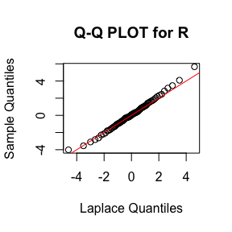

```r
rw.R <- rw.MetropolisR(sigma,x0,N)
rw.C <- rw_MetropolisC(sigma,x0,N)
Q <- ppoints(100)#100 quantiles
Q.T <- q(D)(Q)#TRUE Quantile
Q.RWR <- quantile(rw.R,Q)#Quantile by rw.MetropolisR
qqplot(Q.T, Q.RWR, main="Q-Q PLOT for R", xlab="Laplace Quantiles", ylab="Sample Quantiles")
abline(a = 0,b = 1,col = "RED")#line y=x
```

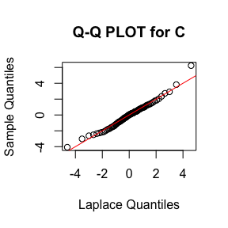

```r
Q.RWC <- quantile(rw.C,Q)#Quantile by rw_MetropolisC
qqplot(Q.T, Q.RWC, main="Q-Q PLOT for C", xlab="Laplace Quantiles", ylab="Sample Quantiles")
abline(a = 0,b = 1,col = "RED")
```

From the time spent, we can see that Cpp takes much less time than R.And from Q-Q plot,the generated random numbers by the two functions are almost equal.